# Pumpkin Classification

Pumpkins, widely grown for food and ornamental purposes, come in various species and varieties, each with unique seed characteristics. These seeds can be categorized based on their physical properties, such as size, shape, and texture. The ability to classify pumpkin seeds can have practical applications in agriculture, seed quality assessment, and even in the food industry, where certain seed types may be preferred for specific products.

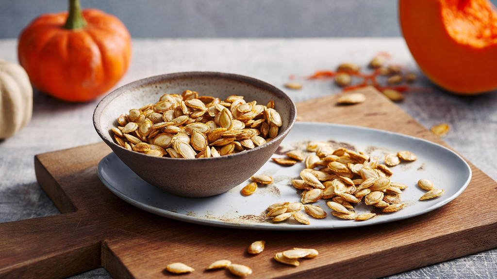

### **| Dataset Overview**

The Pumpkin Seeds Dataset is a comprehensive collection of data that includes measurements and characteristics of different pumpkin seed varieties. The dataset is designed to facilitate classification tasks in the field of agriculture, particularly in distinguishing between different types of pumpkin seeds.

Based on common definitions used in image processing and geometric analysis of objects, especially in the context of biological shapes like seeds. These definitions are derived from general knowledge of how these geometric properties are usually calculated and interpreted in scientific and machine learning contexts. Here's a brief explanation of each:

### **| Features**

1. **`Area` [numeric]:** The total area of the pumpkin seed in pixels.
2. **`Perimeter` [numeric]:** The perimeter length of the seed boundary.
3. **`Major_Axis_Length` [numeric]:** The length of the major axis of the seed, representing the longest diameter.
4. **`Minor_Axis_Length` [numeric]:** The length of the minor axis of the seed, representing the shortest diameter.
5. **`Convex_Area` [numeric]:** The area of the convex hull around the seed, which is the smallest convex shape that can enclose the seed.
6. **`Equiv_Diameter` [numeric]:** The diameter of a circle with the same area as the seed.
7. **`Eccentricity` [numeric]:** A measure of how elongated the seed is, calculated based on the major and minor axis lengths.
8. **`Solidity` [numeric]:** The proportion of the convex area that is filled by the seed (Area/Convex_Area).
9. **`Extent` [numeric]:** The ratio of the seed's area to the area of the bounding box (a rectangle enclosing the seed).
10. **`Roundness` [numeric]:** A measure of how close the shape of the seed is to a perfect circle.
11. **`Aspect_Ratio` [numeric]:** The ratio of the major axis length to the minor axis length.
12. **`Compactness` [numeric]:** A measure combining area and perimeter to reflect how compact the seed is.

### **| Target Variable**

**`Class` [categorical]:** The type or class of the pumpkin seed, which is the target variable for classification.

### **| Project Goals**

1. **`Exploratory Data Analysis (EDA)`**:
   - Understand the structure and distribution of the data.
   - Identify key patterns, trends, and relationships between variables.
2. **`Data Visualization`**:
   - Create visual representations of the data to reveal insights and support analysis.
   - Use plots and charts to highlight important features and correlations.
3. **`Model Building`**:
   - Develop machine learning models to classify the pumpkin seeds.
   - Experiment with different algorithms to find the best-performing model.
4. **`Model Evaluation`**:
   - Assess model performance using relevant metric to ensure accuracy and reliability.

### **| Libraries**

```python
# Importing Libraries
import numpy as np
import pandas as pd
import matplotlib
import matplotlib.pyplot as plt
import seaborn as sns
```

```python
# Reading the weather type dataset
df = pd.read_csv(r"C:\Users\user\Downloads\Pumpkin_Seeds_Dataset.csv")
```

### **| EDA**

```python
print(f'Number of rows in dataset = {df.shape[0]}')
print(f'Number of columns in dataset = {df.shape[1]}')
```

```
Number of rows in dataset = 2500
Number of columns in dataset = 13
```

```python
df.head()
```

|  | Area | Perimeter | Major_Axis_Length | Minor_Axis_Length | Convex_Area | Equiv_Diameter | Eccentricity | Solidity | Extent | Roundness | Aspect_Ration | Compactness | Class |
| --- | --- | --- | --- | --- | --- | --- | --- | --- | --- | --- | --- | --- | --- |
| 0 | 56276 | 888.242 | 326.1485 | 220.2388 | 56831 | 267.6805 | 0.7376 | 0.9902 | 0.7453 | 0.8963 | 1.4809 | 0.8207 | Çerçevelik |
| 1 | 76631 | 1068.146 | 417.1932 | 234.2289 | 77280 | 312.3614 | 0.8275 | 0.9916 | 0.7151 | 0.8440 | 1.7811 | 0.7487 | Çerçevelik |
| 2 | 71623 | 1082.987 | 435.8328 | 211.0457 | 72663 | 301.9822 | 0.8749 | 0.9857 | 0.7400 | 0.7674 | 2.0651 | 0.6929 | Çerçevelik |
| 3 | 66458 | 992.051 | 381.5638 | 222.5322 | 67118 | 290.8899 | 0.8123 | 0.9902 | 0.7396 | 0.8486 | 1.7146 | 0.7624 | Çerçevelik |
| 4 | 66107 | 998.146 | 383.8883 | 220.4545 | 67117 | 290.1207 | 0.8187 | 0.9850 | 0.6752 | 0.8338 | 1.7413 | 0.7557 | Çerçevelik |

```python
df.tail()
```

|  | Area | Perimeter | Major_Axis_Length | Minor_Axis_Length | Convex_Area | Equiv_Diameter | Eccentricity | Solidity | Extent | Roundness | Aspect_Ration | Compactness | Class |
| --- | --- | --- | --- | --- | --- | --- | --- | --- | --- | --- | --- | --- | --- |
| 2495 | 79637 | 1224.710 | 533.1513 | 190.4367 | 80381 | 318.4289 | 0.9340 | 0.9907 | 0.4888 | 0.6672 | 2.7996 | 0.5973 | Ürgüp Sivrisi |
| 2496 | 69647 | 1084.318 | 462.9416 | 191.8210 | 70216 | 297.7874 | 0.9101 | 0.9919 | 0.6002 | 0.7444 | 2.4134 | 0.6433 | Ürgüp Sivrisi |
| 2497 | 87994 | 1210.314 | 507.2200 | 222.1872 | 88702 | 334.7199 | 0.8990 | 0.9920 | 0.7643 | 0.7549 | 2.2828 | 0.6599 | Ürgüp Sivrisi |
| 2498 | 80011 | 1182.947 | 501.9065 | 204.7531 | 80902 | 319.1758 | 0.9130 | 0.9890 | 0.7374 | 0.7185 | 2.4513 | 0.6359 | Ürgüp Sivrisi |
| 2499 | 84934 | 1159.933 | 462.8951 | 234.5597 | 85781 | 328.8485 | 0.8621 | 0.9901 | 0.7360 | 0.7933 | 1.9735 | 0.7104 | Ürgüp Sivrisi |

```python
df.info()
```

```
<class 'pandas.core.frame.DataFrame'>
RangeIndex: 2500 entries, 0 to 2499
Data columns (total 13 columns):
 #   Column             Non-Null Count  Dtype
---  ------             --------------  -----
 0   Area               2500 non-null   int64
 1   Perimeter          2500 non-null   float64
 2   Major_Axis_Length  2500 non-null   float64
 3   Minor_Axis_Length  2500 non-null   float64
 4   Convex_Area        2500 non-null   int64
 5   Equiv_Diameter     2500 non-null   float64
 6   Eccentricity       2500 non-null   float64
 7   Solidity           2500 non-null   float64
 8   Extent             2500 non-null   float64
 9   Roundness          2500 non-null   float64
 10  Aspect_Ration      2500 non-null   float64
 11  Compactness        2500 non-null   float64
 12  Class              2500 non-null   object
dtypes: float64(10), int64(2), object(1)
memory usage: 254.0+ KB
```

```python
# Find and count duplicate records if any
num_duplicates = len(df[df.duplicated()])

print("Number of duplicate records:", num_duplicates)
```

```
Number of duplicate records: 0
```

```python
# Find and count null values if any
df.isnull().sum()
```

```
Area                 0
Perimeter            0
Major_Axis_Length    0
Minor_Axis_Length    0
Convex_Area          0
Equiv_Diameter       0
Eccentricity         0
Solidity             0
Extent               0
Roundness            0
Aspect_Ration        0
Compactness          0
Class                0
dtype: int64
```

### **| Univariate Analysis**

```python
def plot_distribution(df, feature, plot_title):
    with plt.style.context('seaborn-whitegrid'):
        fig, ax = plt.subplots(1, 2, figsize=(20, 5))

        # Colors for pumpkin seeds theme
        hist_color = '#F5B04B'  # Pumpkin Orange
        box_color = '#F5B04B'   # Autumn Brown

        # Histogram
        sns.histplot(x=feature,
                     data=df,
                     ax=ax[0],
                     linewidth=0.7,
                     color=hist_color,
                     bins=20).set_title(f"Distribution of {plot_title}")
        ax[0].set_xlabel(plot_title)

        # Box plot for the entire distribution
        sns.boxplot(x=feature,
                    data=df,
                    linewidth=1.4,
                    width=0.5,
                    color=box_color,
                    ax=ax[1]).set_title(f"Box Plot of {plot_title}")
        ax[1].set_xlabel(plot_title)

        plt.show()
```

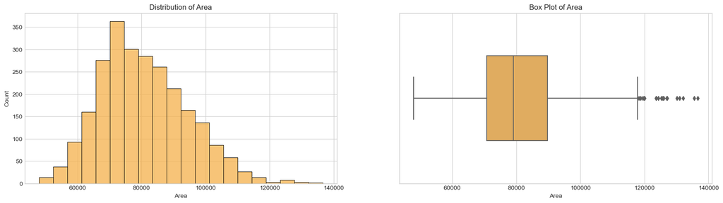

```python
plot_distribution(df, 'Area', 'Area')
```

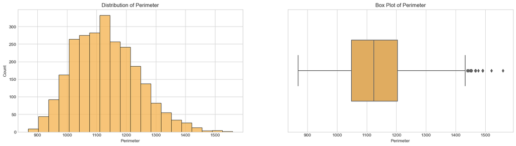

```python
plot_distribution(df, 'Perimeter', 'Perimeter')
```

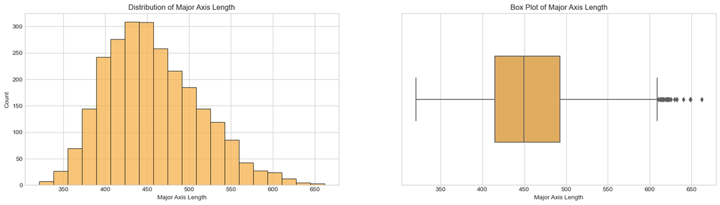

```python
plot_distribution(df, 'Major_Axis_Length', 'Major Axis Length')
```

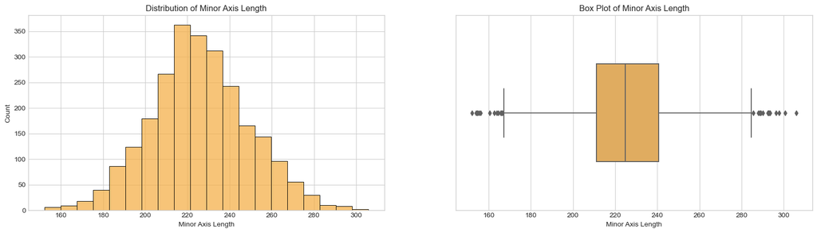

```python
plot_distribution(df, 'Minor_Axis_Length', 'Minor Axis Length')
```

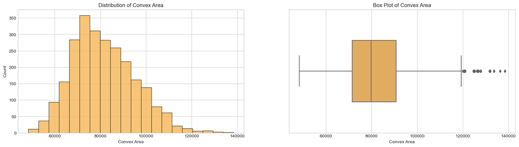

```python
plot_distribution(df, 'Convex_Area', 'Convex Area')
```

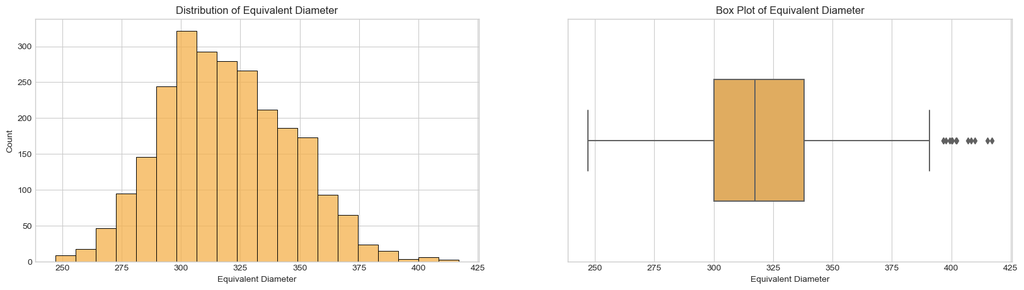

```python
plot_distribution(df, 'Equiv_Diameter', 'Equivalent Diameter')
```

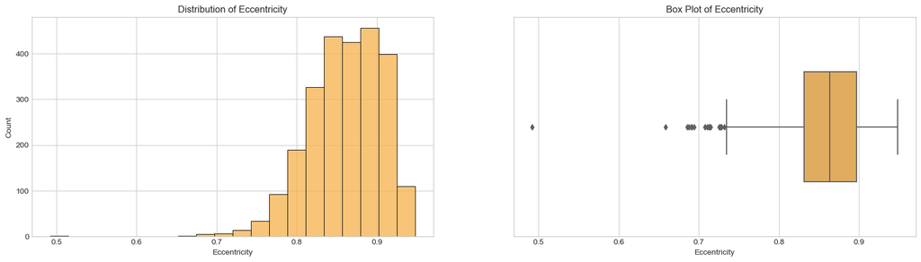

```python
plot_distribution(df, 'Eccentricity', 'Eccentricity')
```

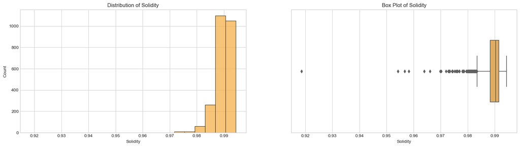

```python
plot_distribution(df, 'Solidity', 'Solidity')
```

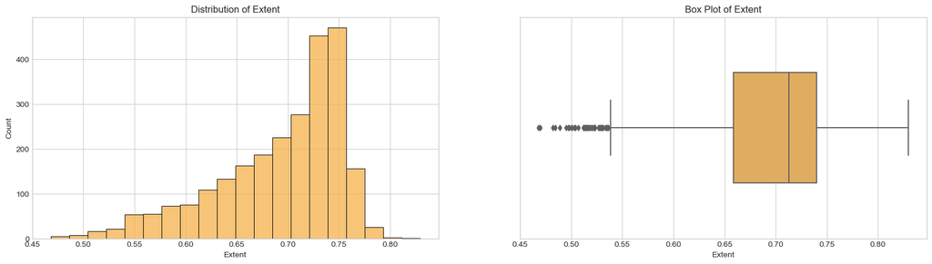

```python
plot_distribution(df, 'Extent', 'Extent')
```

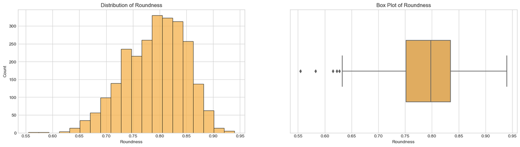

```python
plot_distribution(df, 'Roundness', 'Roundness')
```

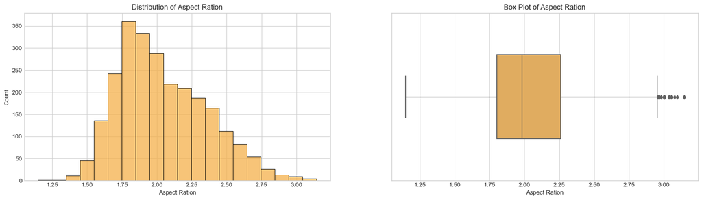

```python
plot_distribution(df, 'Aspect_Ration', 'Aspect Ration')
```

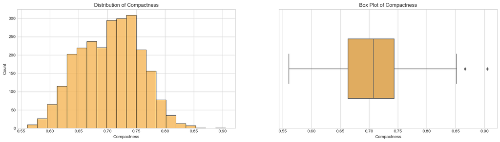

```python
plot_distribution(df, 'Compactness', 'Compactness')
```

### **| Multivariate Analysis**

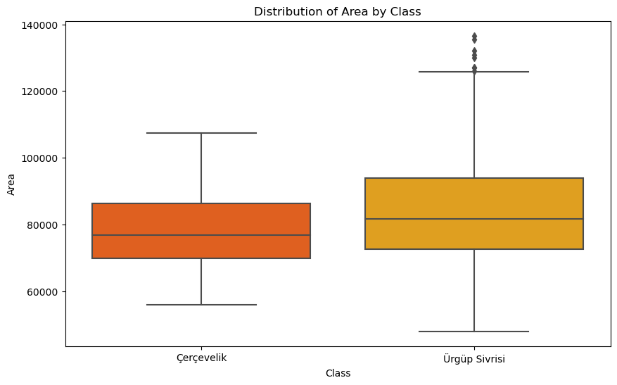

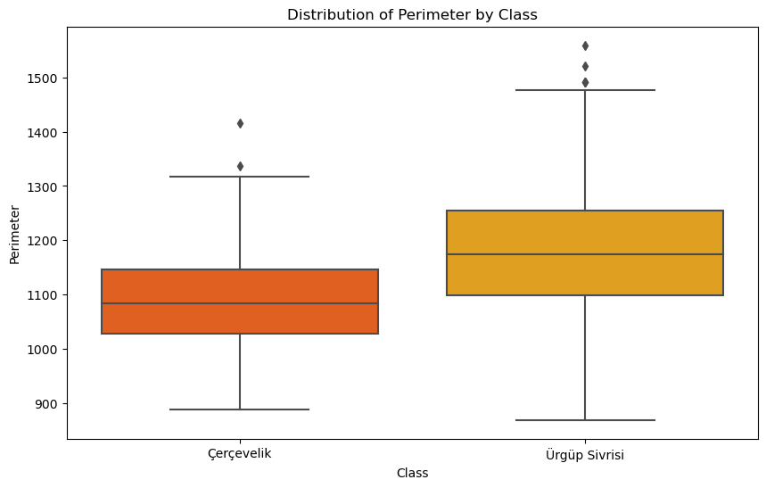

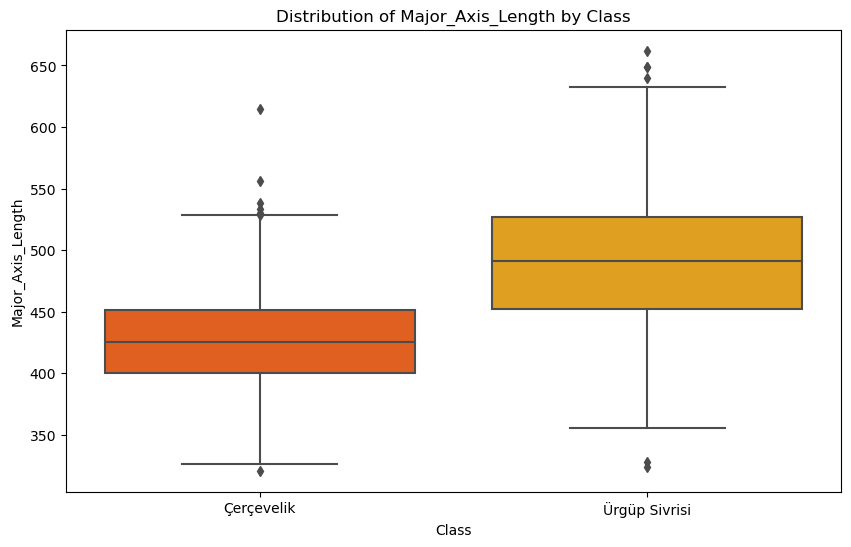

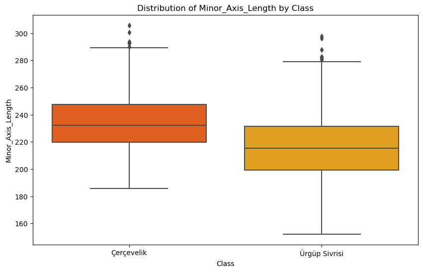

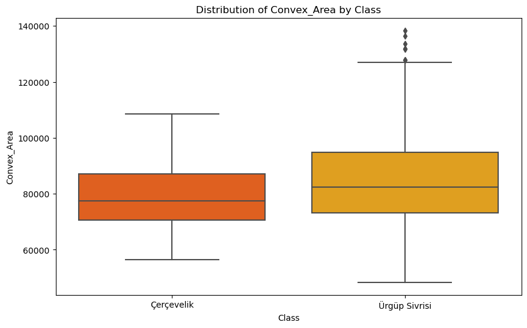

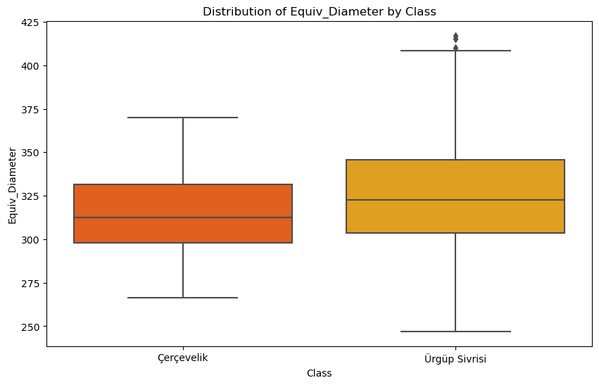

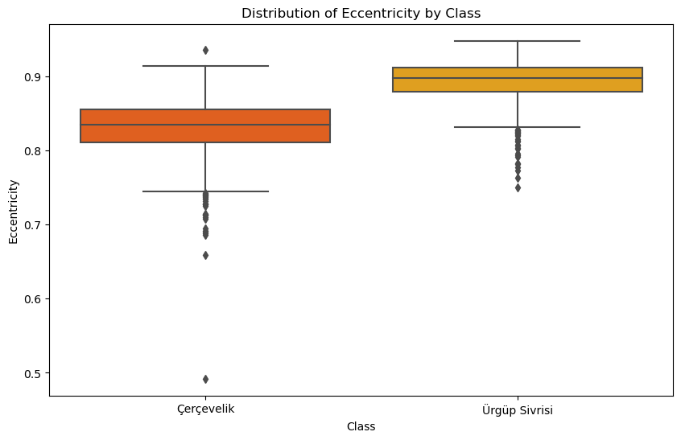

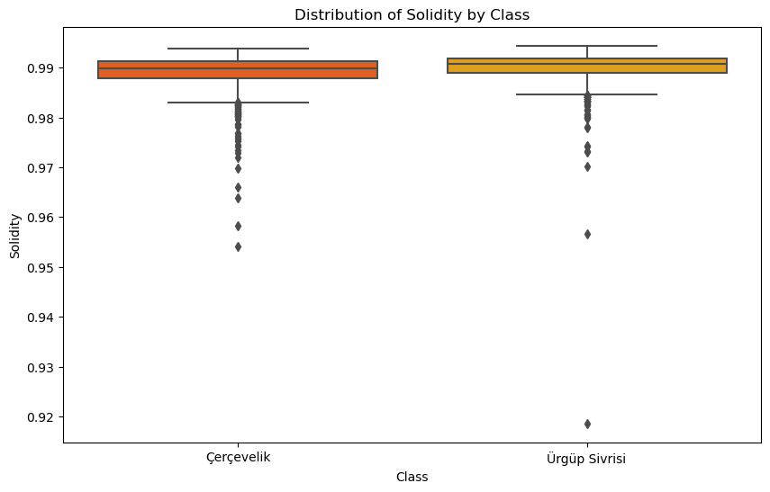

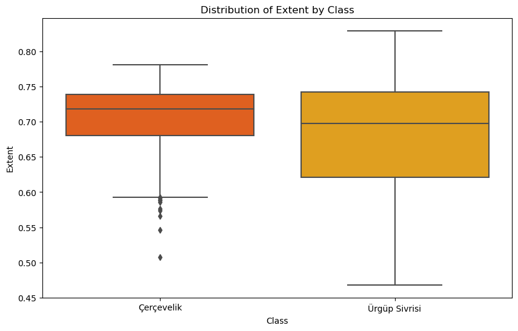

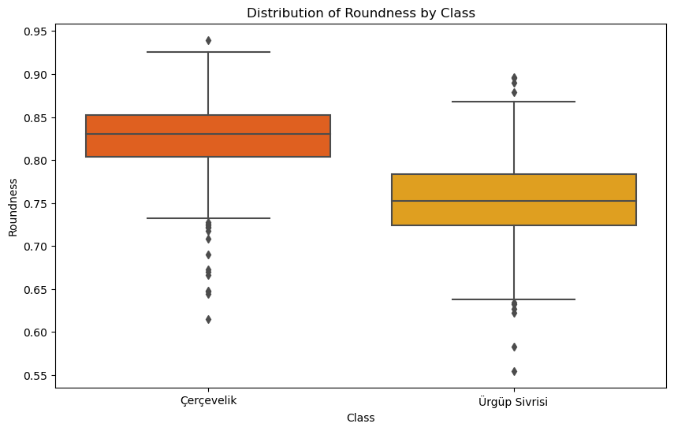

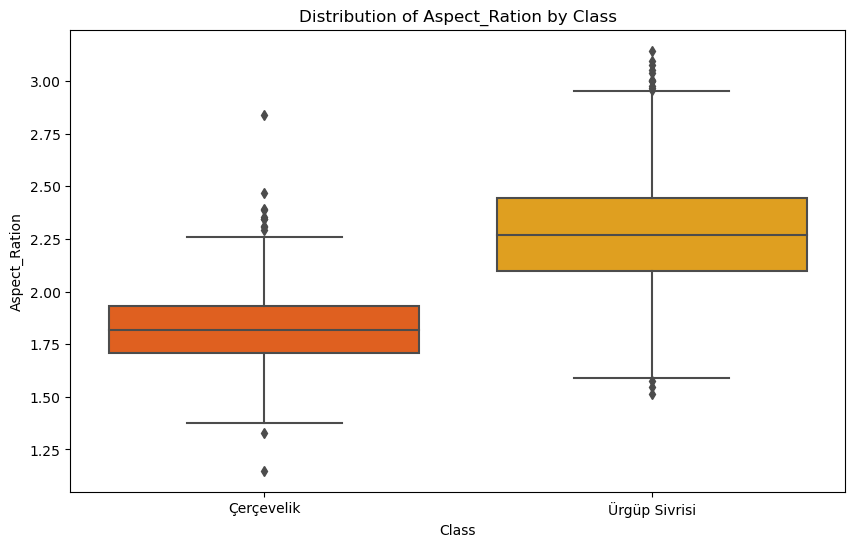

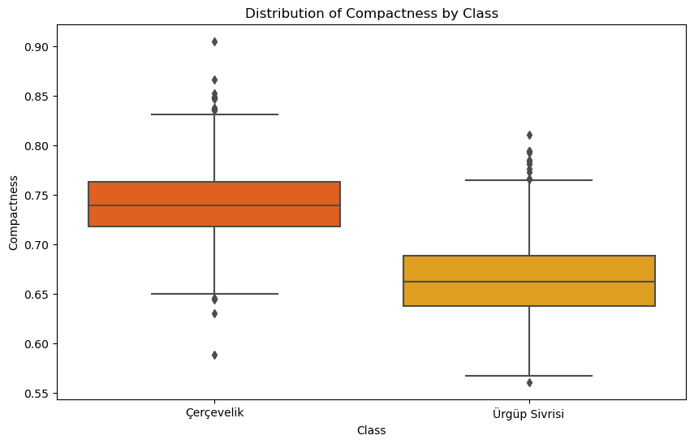

```python
for feature in df.columns[:-1]:
    plt.figure(figsize=(10, 6))
    sns.boxplot(x='Class', y=feature, data=df, palette='autumn')
    plt.title(f'Distribution of {feature} by Class')
    plt.show()
```

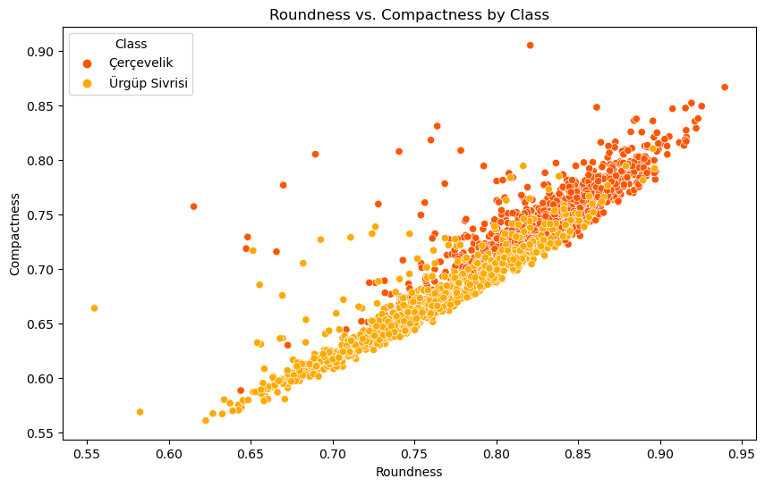

```python
plt.figure(figsize=(10, 6))
sns.scatterplot(x='Roundness', y='Compactness', hue='Class', data=df, palette='autumn')
plt.title('Roundness vs. Compactness by Class')
plt.show()
```